```python
'''
@title: Assignment 2
@author: 鄭子萱(r07741023)
@date: 2019/03/17

'''
```

```
'\n@title: Assignment 2\n@author: 鄭子萱(r07741023)\n@date: 2019/03/17\n\n'
```

# Q1

##### Conduct exploratory analysis on this dataset. You should at least provide summary statistics and visualizations of the key variables. Moreover, you should discuss the characteristics of this dataset.

I will explore the data by descriptive statistics, correlation and the distributions:

```python
import pandas as pd
import numpy as np
import matplotlib.pyplot as plt
import seaborn as sns
%matplotlib inline

import warnings
warnings.filterwarnings("ignore")
```

```python
# import the data
df_train = pd.read_csv('df1_train.csv')
x_test = pd.read_csv('df1_test1.csv')
y_test = pd.read_csv('df1_test1y.csv')

# take a look of the data
df_train.head()
```

|  | life_post_consumer | comp_page_like | Paid | life_post_reach | life_post_impression_liked | life_post_reach_liked | comment | like | share | type_link | ... | hour5 | hour6 | hour7 | hour8 | hour9 | hour10 | hour11 | hour12 | hour13 | hour14 |
| --- | --- | --- | --- | --- | --- | --- | --- | --- | --- | --- | --- | --- | --- | --- | --- | --- | --- | --- | --- | --- | --- |
| 0 | 523 | 125612 | 0 | 2763 | 3519 | 2124 | 0 | 62 | 10 | 0 | ... | 0 | 0 | 0 | 0 | 0 | 0 | 0 | 0 | 0 | 0 |
| 1 | 408 | 135700 | 0 | 3756 | 4935 | 2556 | 16 | 117 | 30 | 0 | ... | 0 | 0 | 0 | 0 | 0 | 0 | 1 | 0 | 0 | 0 |
| 2 | 37 | 137020 | 1 | 1357 | 2154 | 1120 | 0 | 0 | 0 | 0 | ... | 0 | 0 | 0 | 0 | 1 | 0 | 0 | 0 | 0 | 0 |
| 3 | 808 | 137893 | 1 | 37376 | 22100 | 10880 | 20 | 411 | 74 | 0 | ... | 0 | 0 | 0 | 0 | 0 | 0 | 0 | 0 | 0 | 0 |
| 4 | 359 | 133594 | 0 | 1809 | 2541 | 1435 | 2 | 64 | 7 | 0 | ... | 0 | 0 | 0 | 1 | 0 | 0 | 0 | 0 | 0 | 0 |

5 rows × 44 columns

```python
# description and information
print('row/col --\n', df_train.shape, '\n\n')
print('description --\n', df_train.describe(), '\n\n', 'information --\n')
print(df_train.info())
```

```
row/col --
 (400, 44)


description --
        life_post_consumer  comp_page_like        Paid  life_post_reach  \
count          400.000000      400.000000  400.000000       400.000000
mean           810.340000   122890.625000    0.260000     13436.855000
std            899.037251    16280.121461    0.439184     20454.614675
min             17.000000    81370.000000    0.000000       238.000000
25%            335.000000   112676.000000    0.000000      3282.500000
50%            554.500000   128816.000000    0.000000      5150.000000
75%            955.500000   136393.000000    1.000000     13232.000000
max          11328.000000   139441.000000    1.000000    139008.000000

       life_post_impression_liked  life_post_reach_liked     comment  \
count                4.000000e+02             400.000000  400.000000
mean                 1.747735e+04            6585.952500    6.855000
std                  6.614514e+04            7599.228501   14.402519
min                  5.670000e+02             236.000000    0.000000
25%                  3.962500e+03            2171.000000    1.000000
50%                  6.214500e+03            3391.000000    3.000000
75%                  1.510450e+04            8011.000000    7.000000
max                  1.107833e+06           48368.000000  146.000000

             like       share   type_link    ...           hour5       hour6  \
count   400.00000  400.000000  400.000000    ...      400.000000  400.000000
mean    169.07250   25.485000    0.037500    ...        0.022500    0.030000
std     243.14837   25.946248    0.190221    ...        0.148489    0.170801
min       0.00000    0.000000    0.000000    ...        0.000000    0.000000
25%      55.75000   10.000000    0.000000    ...        0.000000    0.000000
50%      98.00000   18.500000    0.000000    ...        0.000000    0.000000
75%     187.25000   32.000000    0.000000    ...        0.000000    0.000000
max    1998.00000  208.000000    1.000000    ...        1.000000    1.000000

            hour7       hour8       hour9      hour10      hour11      hour12  \
count  400.000000  400.000000  400.000000  400.000000  400.000000  400.000000
mean     0.032500    0.022500    0.062500    0.150000    0.092500    0.055000
std      0.177546    0.148489    0.242365    0.357519    0.290093    0.228266
min      0.000000    0.000000    0.000000    0.000000    0.000000    0.000000
```

[output cut: 54 more lines]

```
hour3                         400 non-null int64
hour4                         400 non-null int64
hour5                         400 non-null int64
hour6                         400 non-null int64
hour7                         400 non-null int64
hour8                         400 non-null int64
hour9                         400 non-null int64
hour10                        400 non-null int64
hour11                        400 non-null int64
hour12                        400 non-null int64
hour13                        400 non-null int64
hour14                        400 non-null int64
dtypes: int64(44)
memory usage: 137.6 KB
None
```

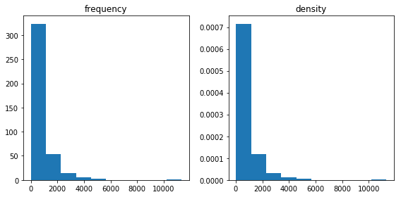

```python
# the distribution of y
fig, (ax0, ax1) = plt.subplots(ncols=2, figsize=(8, 4))

y_train = df_train['life_post_consumer']
ax0.hist(y_train)
ax0.set_title('frequency')

ax1.hist(y_train, density=True)
ax1.set_title('density')

fig.tight_layout()
plt.show()
```

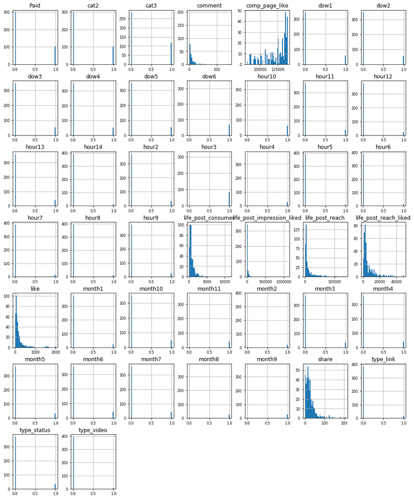

```python
# the distribution of numerical data
list(set(df_train.dtypes.tolist()))
df_num = df_train.select_dtypes(include = ['float64', 'int64'])
df_num.hist(figsize=(16, 20), bins=50, xlabelsize=8, ylabelsize=8);
```

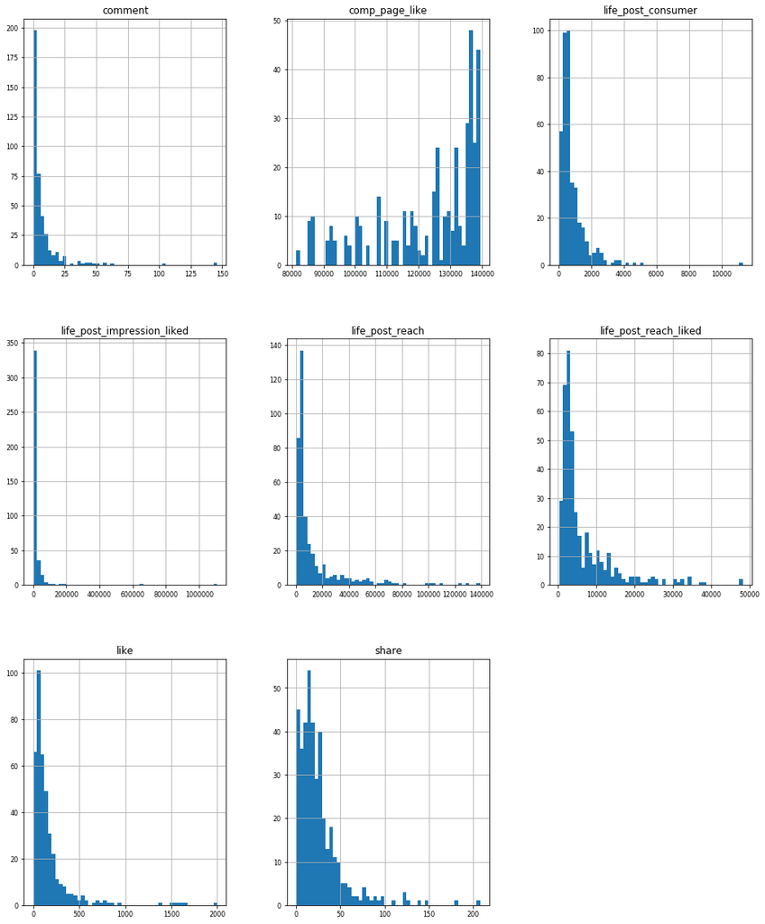

```python
# see the distribution of non-dummy variables
df_non = df_train.iloc[:,[0,1,3,4,5,6,7,8]]
df_non.hist(figsize=(16, 20), bins=50, xlabelsize=8, ylabelsize=8);
```

```python
# correlation
df_num_corr = df_train.corr()['life_post_consumer'][1:]
high_corr = df_num_corr[abs(df_num_corr) >= 0].sort_values(ascending=False).head()
print("Top {} correlated values with outcome variable:\n{}".format(len(high_corr), high_corr))
```

```
Top 5 correlated values with outcome variable:
life_post_reach          0.481325
life_post_reach_liked    0.478766
type_status              0.397365
share                    0.341959
like                     0.306460
Name: life_post_consumer, dtype: float64
```

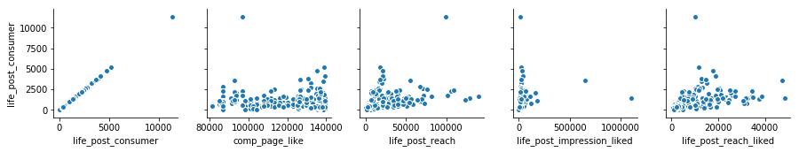

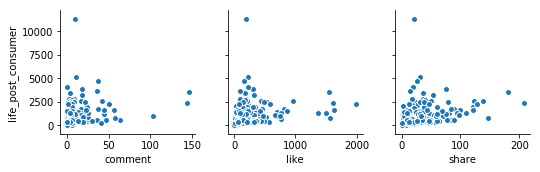

```python
# see the scatter plot of non-dummy variable
for i in range(0, len(df_non.columns), 5):
    sns.pairplot(data=df_non,
                x_vars=df_non.columns[i:i+5],
                y_vars=['life_post_consumer'])
```

According to the EDA, we got some basic information and insights of the data:

1. There are 400 row data and 44 columns, inculding one predited variable and 43 features in the dataset
2. There are no missing values in this dataset.
3. The features inculded 7 numerical variables and 36 dummy variables
4. We can find that there are some outliers, but I think those outliers would be somehow meaningful. I decide to keep it at the moment.
5. The correlation of features and outcome are all below 0.5 which means the relationship between outcome and features are week. But we still can figure out the top 5 correlated features.
6. The distribution of y is quite skewed right, since there are some outliers.

# Q2

##### a prediction model using the setting of Case 1. What is the test RMSE? What are the predictions and true outcome values for the first 20 data points in the testing data?

Since case 1 only use mean as prediction, I just need to calculate the mean of y of training data:

```python
y_mean = df_train['life_post_consumer'].mean()
y_pred0 = [y_mean] * len(y_test)

# rmse
rmse0 = np.sqrt(np.mean(np.square(y_test['life_post_consumer'] - y_pred0)))
print('1. rmse:', rmse0, '\n\n')

# first 20 predictions
y_pred0 = [y_mean] * 20
y_first0 = y_test.iloc[0:20,]
y_first0['y_pred'] = y_pred0
print('2. first 20 predictions: \n\n', y_first0)
```

```
1. rmse: 928.809510933216


2. first 20 predictions:

     life_post_consumer  y_pred
0                 1183  810.34
1                  189  810.34
2                 2327  810.34
3                   76  810.34
4                  354  810.34
5                  713  810.34
6                  204  810.34
7                  288  810.34
8                  555  810.34
9                  586  810.34
10                 446  810.34
11                 884  810.34
12                 524  810.34
13                 672  810.34
14                  23  810.34
15                 570  810.34
16                1361  810.34
17                5934  810.34
18                2319  810.34
19                1633  810.34
```

# Q3 (Case 2A: OLS)

```python
y_train = df_train['life_post_consumer']
x_train = df_train.drop(df_train.columns[0], axis=1)
```

```python
from sklearn import linear_model

#Train the model using the training sets
reg1 = linear_model.LinearRegression(fit_intercept=True)
reg1.fit(x_train, y_train)

# Make predictions using the testing set
y_pred1 = reg1.predict(x_test)

# rmse
rmse1 = np.sqrt(np.mean(np.square(y_test['life_post_consumer'] - y_pred1)))
print('1. rmse:', rmse1, '\n\n')

# first 20 predictions
y_first1= y_test.iloc[0:20,]
y_first1['y_pred'] = y_pred1[0:20]
print('2. first 20 predictions: \n\n', y_first1)
```

```
1. rmse: 692.2891271362122


2. first 20 predictions:

     life_post_consumer       y_pred
0                 1183   781.579915
1                  189   315.920431
2                 2327  2279.084852
3                   76  -136.342864
4                  354   302.356241
5                  713   462.424024
6                  204   321.677708
7                  288   504.522448
8                  555   505.895471
9                  586   488.367006
10                 446   392.614235
11                 884   388.918467
12                 524   804.875275
13                 672   634.323644
14                  23   176.317656
15                 570   645.729138
16                1361  1983.538589
17                5934  3144.397100
18                2319  4060.610712
19                1633  4288.223081
```

# Q4 (Case 2B: OLS)

```python
# convert y_train/ y_test to de-mean
y_train_de = y_train - y_mean

#Train the model using the training sets
reg2 = linear_model.LinearRegression(fit_intercept=True)
reg2.fit(x_train, y_train_de)

# Make predictions using the testing set
y_pred2 = reg2.predict(x_test)
y_pred2 = y_pred2 + y_mean

# rmse
rmse2 = np.sqrt(np.mean(np.square(y_test['life_post_consumer'] - y_pred2)))
print('1. rmse:', rmse2, '\n\n')

# first 20 predictions
y_first2 = y_test.iloc[0:20,]
y_first2['y_pred'] = y_pred2[0:20]
print('2. first 20 predictions: \n\n', y_first2)
```

```
1. rmse: 692.2891271362292


2. first 20 predictions:

     life_post_consumer       y_pred
0                 1183   781.579915
1                  189   315.920431
2                 2327  2279.084852
3                   76  -136.342864
4                  354   302.356241
5                  713   462.424024
6                  204   321.677708
7                  288   504.522448
8                  555   505.895471
9                  586   488.367006
10                 446   392.614235
11                 884   388.918467
12                 524   804.875275
13                 672   634.323644
14                  23   176.317656
15                 570   645.729138
16                1361  1983.538589
17                5934  3144.397100
18                2319  4060.610712
19                1633  4288.223081
```

# Q5(Case 2C)

```python
from sklearn import preprocessing

xscaler = preprocessing.StandardScaler().fit(x_train.values)
#standardize feature values
x_train_sd = xscaler.transform(x_train)
x_test_sd = xscaler.transform(x_test)

#Train the model using the training sets
reg3 = linear_model.LinearRegression()
reg3.fit(x_train_sd, y_train_de)

# Make predictions using the testing set
y_pred3 = reg3.predict(x_test_sd)
y_pred3 = y_pred3 + y_mean

# rmse
rmse3 = np.sqrt(np.mean(np.square(y_test['life_post_consumer'] - y_pred3)))
print('1. rmse:', rmse3, '\n\n')

# first 20 predictions
y_first3 = y_test.iloc[0:20,]
y_first3['y_pred'] = y_pred3[0:20]
print('2. first 20 predictions: \n\n', y_first3)
```

```
1. rmse: 692.2891271371998


2. first 20 predictions:

     life_post_consumer       y_pred
0                 1183   781.579915
1                  189   315.920431
2                 2327  2279.084852
3                   76  -136.342864
4                  354   302.356241
5                  713   462.424024
6                  204   321.677708
7                  288   504.522448
8                  555   505.895471
9                  586   488.367006
10                 446   392.614235
11                 884   388.918467
12                 524   804.875275
13                 672   634.323644
14                  23   176.317656
15                 570   645.729138
16                1361  1983.538589
17                5934  3144.397100
18                2319  4060.610712
19                1633  4288.223081
```

# Q6 (Case 3A)

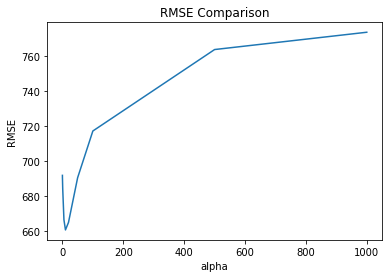

```python
# given information
alpha_list = [0.01, 0.1, 1, 5, 10, 20, 50, 100, 500, 1000]
rmse_optimal = 1000
rmse_all = []

for a in alpha_list:
    reg = linear_model.Ridge(fit_intercept=True, alpha=a)
    reg.fit(x_train, y_train)
    y_pred = reg.predict(x_test)
    rmse = np.sqrt(np.mean(np.square(y_test['life_post_consumer'] - y_pred)))

    if rmse < rmse_optimal:
        rmse_optimal = rmse
        alpha_optimal = a
        y_pred_optimal = y_pred

    rmse_all.append(rmse)

fig, ax = plt.subplots()
ax.plot(alpha_list, rmse_all)
ax.set(xlabel='alpha', ylabel='RMSE', title='RMSE Comparison')
plt.show()
```

```python
# rmse
rmse_rr = np.sqrt(np.mean(np.square(y_test['life_post_consumer'] - y_pred_optimal)))
print('1. the best rmse:', rmse_rr, ', alpha:',alpha_optimal,'\n\n')

# first 20 predictions
y_pred_rr= y_test.iloc[0:20,]
y_pred_rr['y_pred'] = y_pred_optimal[0:20]
print('2. first 20 predictions: \n\n', y_pred_rr)
```

```
1. the best rmse: 660.5612900111674 , alpha: 10


2. first 20 predictions:

     life_post_consumer       y_pred
0                 1183  1068.333624
1                  189   229.755319
2                 2327  2008.558892
3                   76  -102.874899
4                  354   541.457699
5                  713   606.459258
6                  204   414.982798
7                  288   602.810514
8                  555   500.184385
9                  586   492.306636
10                 446   508.376500
11                 884   409.130022
12                 524   730.467680
13                 672   561.060328
14                  23   294.450897
15                 570   602.482867
16                1361  1632.182715
17                5934  2698.882818
18                2319  3841.631528
19                1633  3892.400909
```

# Q7 (Case 3B: std/keep/de-mean)

```python
# pre processing the dataframe
xc_train = x_train.iloc[:,[0,2,3,4,5,6,7]]
xc_test = x_test.iloc[:,[0,2,3,4,5,6,7]]
xb_train = x_train.drop(x_train.columns[[0,2,3,4,5,6,7]], axis=1)
xb_test = x_test.drop(x_train.columns[[0,2,3,4,5,6,7]], axis=1)
```

```python
xscaler = preprocessing.StandardScaler().fit(xc_train.values)
#standardize continious variables
xc_train_sd = xscaler.transform(xc_train)
xc_test_sd = xscaler.transform(xc_test)

#merge continious and binary variables
x_train_sd_c = np.concatenate((xc_train_sd, xb_train.values), axis=1)
x_test_sd_c =  np.concatenate((xc_test_sd, xb_test.values), axis=1)
```

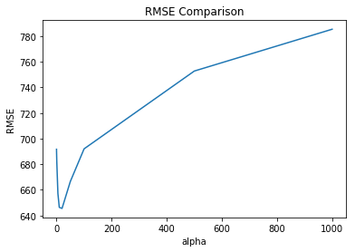

```python
# given information
alpha_list = [0.01, 0.1, 1, 5, 10, 20, 50, 100, 500, 1000]
rmse_optimal = 1000
rmse_all = []

for a in alpha_list:
    reg = linear_model.Ridge(fit_intercept=True, alpha=a)
    reg.fit(x_train_sd_c, y_train_de)
    y_pred = reg.predict(x_test_sd_c)
    y_pred = y_pred + y_mean

    rmse = np.sqrt(np.mean(np.square(y_test['life_post_consumer'] - y_pred)))

    if rmse < rmse_optimal:
        rmse_optimal = rmse
        alpha_optimal = a
        y_pred_optimal = y_pred

    rmse_all.append(rmse)

fig, ax = plt.subplots()
ax.plot(alpha_list, rmse_all)
ax.set(xlabel='alpha', ylabel='RMSE', title='RMSE Comparison')
plt.show()
```

```python
# rmse
rmse_rr = np.sqrt(np.mean(np.square(y_test['life_post_consumer'] - y_pred_optimal)))
print('1. the best rmse:', rmse_rr, ', alpha:',alpha_optimal,'\n\n')

# first 20 predictions
y_pred_rr= y_test.iloc[0:20,]
y_pred_rr['y_pred'] = y_pred_optimal[0:20]
print('2. first 20 predictions: \n\n', y_pred_rr)
```

```
1. the best rmse: 645.5168123938738 , alpha: 20


2. first 20 predictions:

     life_post_consumer       y_pred
0                 1183  1142.269542
1                  189   254.157015
2                 2327  1834.024889
3                   76    15.718169
4                  354   599.763663
5                  713   635.940390
6                  204   427.856444
7                  288   603.662060
8                  555   514.523788
9                  586   580.001060
10                 446   544.341760
11                 884   477.184421
12                 524   801.545545
13                 672   557.452872
14                  23   396.278865
15                 570   615.151524
16                1361  1474.674174
17                5934  2504.864373
18                2319  3524.859645
19                1633  3438.403437
```

# Q8 (Case 3C: keep/keep/demean)

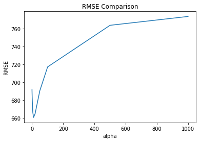

```python
# given information
alpha_list = [0.01, 0.1, 1, 5, 10, 20, 50, 100, 500, 1000]
rmse_optimal = 1000
rmse_all = []

for a in alpha_list:
    reg = linear_model.Ridge(fit_intercept=True, alpha=a)
    reg.fit(x_train, y_train_de)
    y_pred = reg.predict(x_test)
    y_pred = y_pred + y_mean
    rmse = np.sqrt(np.mean(np.square(y_test['life_post_consumer'] - y_pred)))

    if rmse < rmse_optimal:
        rmse_optimal = rmse
        alpha_optimal = a
        y_pred_optimal = y_pred

    rmse_all.append(rmse)

fig, ax = plt.subplots()
ax.plot(alpha_list, rmse_all)
ax.set(xlabel='alpha', ylabel='RMSE', title='RMSE Comparison')
plt.show()
```

```python
# rmse
rmse_rr = np.sqrt(np.mean(np.square(y_test['life_post_consumer'] - y_pred_optimal)))
print('1. the best rmse:', rmse_rr, ', alpha:',alpha_optimal,'\n\n')

# first 20 predictions
y_pred_rr= y_test.iloc[0:20,]
y_pred_rr['y_pred'] = y_pred_optimal[0:20]
print('2. first 20 predictions: \n\n', y_pred_rr)
```

```
1. the best rmse: 660.5612900111671 , alpha: 10


2. first 20 predictions:

     life_post_consumer       y_pred
0                 1183  1068.333624
1                  189   229.755319
2                 2327  2008.558892
3                   76  -102.874899
4                  354   541.457699
5                  713   606.459258
6                  204   414.982798
7                  288   602.810514
8                  555   500.184385
9                  586   492.306636
10                 446   508.376500
11                 884   409.130022
12                 524   730.467680
13                 672   561.060328
14                  23   294.450897
15                 570   602.482867
16                1361  1632.182715
17                5934  2698.882818
18                2319  3841.631528
19                1633  3892.400909
```

# Q9 (Case 3D std/std/dmean)

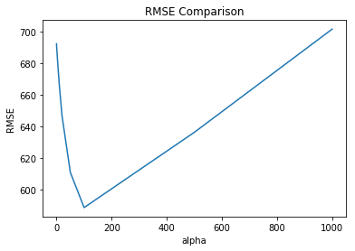

```python
# given information
alpha_list = [0.01, 0.1, 1, 5, 10, 20, 50, 100, 500, 1000]
rmse_optimal = 1000
rmse_all = []

for a in alpha_list:
    reg = linear_model.Ridge(fit_intercept=True, alpha=a)
    reg.fit(x_train_sd, y_train_de)
    y_pred = reg.predict(x_test_sd)
    y_pred = y_pred + y_mean
    rmse = np.sqrt(np.mean(np.square(y_test['life_post_consumer'] - y_pred)))

    if rmse < rmse_optimal:
        rmse_optimal = rmse
        alpha_optimal = a
        y_pred_optimal = y_pred

    rmse_all.append(rmse)

fig, ax = plt.subplots()
ax.plot(alpha_list, rmse_all)
ax.set(xlabel='alpha', ylabel='RMSE', title='RMSE Comparison')
plt.show()
```

```python
# rmse
rmse_rr = np.sqrt(np.mean(np.square(y_test['life_post_consumer'] - y_pred_optimal)))
print('1. the best rmse:', rmse_rr, ', alpha:',alpha_optimal,'\n\n')

# first 20 predictions
y_pred_rr= y_test.iloc[0:20,]
y_pred_rr['y_pred'] = y_pred_optimal[0:20]
print('2. first 20 predictions: \n\n', y_pred_rr)
```

```
1. the best rmse: 588.793465752767 , alpha: 100


2. first 20 predictions:

     life_post_consumer       y_pred
0                 1183  1040.500123
1                  189   278.465050
2                 2327  1997.724464
3                   76   -21.140365
4                  354   554.215257
5                  713   602.840642
6                  204   337.523470
7                  288   599.435785
8                  555   470.293704
9                  586   500.724140
10                 446   511.148619
11                 884   387.743553
12                 524   700.089577
13                 672   532.222810
14                  23   255.183118
15                 570   653.356378
16                1361  1728.169192
17                5934  2775.002711
18                2319  3174.792252
19                1633  3141.857976
```

# Q10 (Case 4 std/keep/demean)

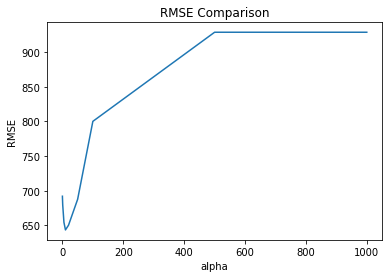

```python
# given information
alpha_list = [0.01, 0.1, 1, 5, 10, 20, 50, 100, 500, 1000]
rmse_optimal = 1000
rmse_all = []

for a in alpha_list:
    reg = linear_model.Lasso(fit_intercept=True, alpha=a)
    reg.fit(x_train_sd_c, y_train_de)
    y_pred = reg.predict(x_test_sd_c)
    y_pred = y_pred + y_mean
    rmse = np.sqrt(np.mean(np.square(y_test['life_post_consumer'] - y_pred)))

    if rmse < rmse_optimal:
        rmse_optimal = rmse
        alpha_optimal = a
        y_pred_optimal = y_pred

    rmse_all.append(rmse)

fig, ax = plt.subplots()
ax.plot(alpha_list, rmse_all)
ax.set(xlabel='alpha', ylabel='RMSE', title='RMSE Comparison')
plt.show()
```

```python
# rmse
rmse_rr = np.sqrt(np.mean(np.square(y_test['life_post_consumer'] - y_pred_optimal)))
print('1. the best rmse:', rmse_rr, ', alpha:',alpha_optimal,'\n\n')

# first 20 predictions
y_pred_rr= y_test.iloc[0:20,]
y_pred_rr['y_pred'] = y_pred_optimal[0:20]
print('2. first 20 predictions: \n\n', y_pred_rr)
```

```
1. the best rmse: 643.3855039398903 , alpha: 10


2. first 20 predictions:

     life_post_consumer       y_pred
0                 1183  1241.595908
1                  189   287.886873
2                 2327  2119.913047
3                   76   -16.300847
4                  354   449.099884
5                  713   711.149683
6                  204   398.058445
7                  288   460.156222
8                  555   645.447721
9                  586   591.433023
10                 446   429.964408
11                 884   461.478992
12                 524   899.808255
13                 672   571.865037
14                  23   352.863435
15                 570   548.089902
16                1361  1741.014530
17                5934  2712.056805
18                2319  3681.471230
19                1633  3645.134974
```

# Q11

1. According to the results, we can easily find that Case3D has the best RMSE, which is 588.793465752767. That is, the Ridge regression outperform other models in this case
1. If we compare the results within the same models, we can find some insights of pre-processing steps as well. Under the OLS model, the impacts of pre-processing is less since the results are nearly the same. However, when using ridge regression, there are big difference of pre-processing. It is better to pre-process data by standardizing all features and de-mean the outcome variable.